# Predicting Quality in Human Activity using Machine Learning

Chad Salinas

## Executive Summary

We will build a machine learning model to predict the quality of 6 study participants performing a weight lifting exercise. Under the supervision an experienced weight lifter, each participant performed 1 set of 10 repetitions of the Unilateral Dumbbell Biceps Curl in 5 different ways:  
(Class A) - exactly according to the specification  
(Class B) - throwing the elbows to the front  
(Class C) - lifting the dumbbell only halfway  
(Class D) - lowering the dumbbell only halfway  
(Class E) - throwing the hips to the front

Class A represents the paragon of excecuting the motion correctly. Using 5 sensors on the participants’ bodies, we use the data to train our model to correctly classify each of 20 test cases into either Class A or one of the other 4 mistake categories with a high degree of accuracy.

## Study Design

Firstly, we tidy up the data as usual. Then, we arrive at our final group of features by excluding highly correlated predictors. Secondly, we split training set into training & cross-validation. We then train our models using training data then apply the models to the cross-validation data to get a sense of the accuracy/out-of-sample error. We test 3 models built off of the training data and assess their accuracy/out-of-sample errors on the cross-validation set. Finally, we use the most accurate of the models on the test data.

Our hypothesis going in is that Random Forests(RF) should be the best predictor. RF is highly accurate in classification problems involving a high number of features wherein it can reduce bias of fitted values and estimated splits. Let’s see if that turns out to be true given this problem instance.

## Exploratory Analysis

We load and explore the data with an eye towards identifying useful, complete, and non-colinear predictors to train our model.

```r
trainUrl <- "http://d396qusza40orc.cloudfront.net/predmachlearn/pml-training.csv"
testUrl <- "http://d396qusza40orc.cloudfront.net/predmachlearn/pml-testing.csv"
trainingData <- read.csv(url(trainUrl), na.strings = c("NA", ""))
```

We initally find 160 columns.  
Firstly, we tidy up the data set by excluding:  
1) NA data  
2) Incomplete data  
3) Useless non-predictor data

```r
# Get rid of NAs and blank cols
trainingData <- trainingData[, colSums(is.na(trainingData)) == 0]

# Get rid of useless non-predictor cols
trainingData <- trainingData[ , -c(1:7)]
```

### Split Data and Identify Final Features

We split off the cross validation data from the training data and then get rid of highly-correlated predictors in the training data.

```r
suppressMessages(library(caret))
```

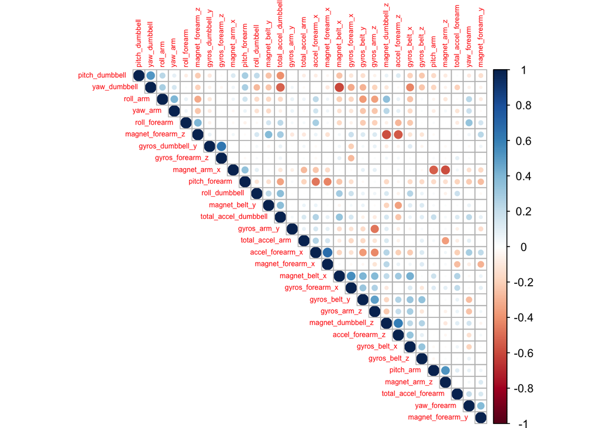

```r
set.seed(1964)
inTrain <- createDataPartition(trainingData$classe, p = 0.8, list = FALSE)
trainingData <- trainingData[inTrain, ]
cvData <- trainingData[-inTrain, ]

suppressMessages(library(corrplot))
M <- cor(trainingData[,-dim(trainingData)[2]],)
highCorVars <- findCorrelation(M, cutoff = 0.7)
finalTrainingData <- trainingData[,-highCorVars]
M <- cor(finalTrainingData[,-dim(finalTrainingData)[2]])
corrplot(M, type = "upper", order = "hclust", addrect = 3, tl.cex = 0.5)
```

```r
# Final predictors
predictors <- names(finalTrainingData[1:(ncol(finalTrainingData) - 1)])
```

Now, we have settled on the final 30 features upon which to train our models to predict classe.

## Fit Model using Decision Tree

We are dealing with a classification problem, so we choose to start our modelling effort with a basic Decision Tree to get a baseline accuracy/out-of-sample error.

```r
dtModelFit <- train(classe~., method="rpart", data=finalTrainingData)
dtCVPredictions <- predict(dtModelFit, cvData[, predictors])
dtCVConfMatrix <- confusionMatrix(dtCVPredictions, cvData$classe)
dtCVConfMatrix
```

```
## Confusion Matrix and Statistics
##
##           Reference
## Prediction   A   B   C   D   E
##          A 807 440 267 280 191
##          B   0   0   0   0   0
##          C  46 170 246  49 183
##          D  13  26  49 123  28
##          E   1   1   0  44 175
##
## Overall Statistics
##
##                Accuracy : 0.4304
##                  95% CI : (0.413, 0.4479)
##     No Information Rate : 0.2762
##     P-Value [Acc > NIR] : < 2.2e-16
##
##                   Kappa : 0.2513
##  Mcnemar's Test P-Value : < 2.2e-16
##
## Statistics by Class:
##
##                      Class: A Class: B Class: C Class: D Class: E
## Sensitivity            0.9308   0.0000  0.43772  0.24798  0.30329
## Specificity            0.4815   1.0000  0.82615  0.95611  0.98205
## Pos Pred Value         0.4065      NaN  0.35447  0.51464  0.79186
## Neg Pred Value         0.9480   0.7971  0.87076  0.87138  0.86223
## Prevalence             0.2762   0.2029  0.17904  0.15801  0.18382
## Detection Rate         0.2571   0.0000  0.07837  0.03918  0.05575
## Detection Prevalence   0.6324   0.0000  0.22109  0.07614  0.07040
## Balanced Accuracy      0.7062   0.5000  0.63194  0.60205  0.64267
```

```r
dtCVConfMatrix$overall[1]
```

```
##  Accuracy
## 0.4303918
```

## Fit Model using GBM

We choose GBM to train our model because other than Random Forests, Boosting models are usually one of the best performers when modeling these sort of classification problems.

```r
gbmCtrl <- trainControl(method = "repeatedcv", number = 5, repeats = 1) #try to speed it up
gbmModelFit  <- train(classe~., data=finalTrainingData, method = "gbm", trControl = gbmCtrl, verbose = FALSE)
gbmCVPredictions <- predict(gbmModelFit, cvData[, predictors])
gbmCVConfMatrix <- confusionMatrix(cvData[, "classe"], gbmCVPredictions)
gbmCVConfMatrix$overall[1]
```

```
##  Accuracy
## 0.9267283
```

The confusion matrix accuracy of 93% on the cross validation data fits our intuition that a boosting model should outperform a basic decision tree for this type of classification problem.  
Now, let’s see if we can do better using a RF model.

## Fit Model using Random Forest

Our choice of Random Forest stems from our willingingness to trade off slowness, interpretability, and overfitting for an expected increase in accuracy over other models.

```r
rfModelFit <- train(classe~., data=finalTrainingData, method = "rf", trControl = trainControl(method = "cv", number = 5))
rfCVPredictions <- predict(rfModelFit, cvData[, predictors])
rfCVConfMatrix <- confusionMatrix(cvData[, "classe"], rfCVPredictions)
rfCVConfMatrix
```

```
## Confusion Matrix and Statistics
##
##           Reference
## Prediction   A   B   C   D   E
##          A 867   0   0   0   0
##          B   0 637   0   0   0
##          C   0   0 562   0   0
##          D   0   0   0 496   0
##          E   0   0   0   0 577
##
## Overall Statistics
##
##                Accuracy : 1
##                  95% CI : (0.9988, 1)
##     No Information Rate : 0.2762
##     P-Value [Acc > NIR] : < 2.2e-16
##
##                   Kappa : 1
##  Mcnemar's Test P-Value : NA
##
## Statistics by Class:
##
##                      Class: A Class: B Class: C Class: D Class: E
## Sensitivity            1.0000   1.0000    1.000    1.000   1.0000
## Specificity            1.0000   1.0000    1.000    1.000   1.0000
## Pos Pred Value         1.0000   1.0000    1.000    1.000   1.0000
## Neg Pred Value         1.0000   1.0000    1.000    1.000   1.0000
## Prevalence             0.2762   0.2029    0.179    0.158   0.1838
## Detection Rate         0.2762   0.2029    0.179    0.158   0.1838
## Detection Prevalence   0.2762   0.2029    0.179    0.158   0.1838
## Balanced Accuracy      1.0000   1.0000    1.000    1.000   1.0000
```

```r
rfCVConfMatrix$overall[1]
```

```
## Accuracy
##        1
```

## Prediction on Test Data

Of the three classification models, Random Forest more accurately classified the cross-validation set. So, now we apply the model to classify the exercise activities based on the hold-out data from 20 test cases.

```r
testingData <- read.csv(url(testUrl))
rfPredictions <- predict(rfModelFit, testingData[, predictors])
rfPredictions
```

```
##  [1] B A B A A E D B A A B C B A E E A B B B
## Levels: A B C D E
```

## Appendix

### References

Velloso, E.; Bulling, A.; Gellersen, H.; Ugulino, W.; Fuks, H. Qualitative Activity Recognition of Weight Lifting Exercises. Proceedings of 4th International Conference in Cooperation with SIGCHI (Augmented Human ’13) . Stuttgart, Germany: ACM SIGCHI, 2013.